# Brain and Music Lab R Crash Course 2024

B&M Workshop Series

Sarah Hennessy & Priscilla Perez

January 19, 2024

# Section I: Basic Introduction

This text here is not code.

```r
# this text is in a code block (a chunk) but it is a comment, so it will not execute
```

## Libraries

```r
# You only need to do this once!
# install.packages("psych")
# install.packages("readxl")
# install.packages("rmarkdown")
```

```r
# you need to do this every time you open R
library(psych)
library(readxl)
library(rmarkdown)
```

## Objects & Value Types

```r
# vector
vec = c("1","2","3","4","5")
vec
```

```
## [1] "1" "2" "3" "4" "5"
```

```r
# factor
fac = factor(c("cat","cat","dog","mouse","dog"))

# matrix, a 2x5
mat = matrix(1:10, ncol = 5)
dim(mat)
```

```
## [1] 2 5
```

```r
mat
```

```
##      [,1] [,2] [,3] [,4] [,5]
## [1,]    1    3    5    7    9
## [2,]    2    4    6    8   10
```

```r
# dataframe
animal <- factor(c("cat","cat","dog","mouse","dog"))
adoptee_number <- c(1:5)
df <- data.frame(adoptee_number,animal)
#View(df)

# list
lis = list(vec,fac,mat)
lis
```

```
## [[1]]
## [1] "1" "2" "3" "4" "5"
##
## [[2]]
## [1] cat   cat   dog   mouse dog
## Levels: cat dog mouse
##
## [[3]]
##      [,1] [,2] [,3] [,4] [,5]
## [1,]    1    3    5    7    9
## [2,]    2    4    6    8   10
```

```r
class(animal)
```

```
## [1] "factor"
```

```r
class(adoptee_number)
```

```
## [1] "integer"
```

```r
adoptee_number= as.numeric(adoptee_number)
class(adoptee_number)
```

```
## [1] "numeric"
```

```r
adoptee_number= as.character(adoptee_number)
class(adoptee_number)
```

```
## [1] "character"
```

```r
adoptee_number= as.factor(adoptee_number)
class(adoptee_number)
```

```
## [1] "factor"
```

## Exploring data

```r
data= read.csv("data.csv")
```

```r
colnames(data)
```

```
## [1] "id"        "age_group" "gender"    "condition" "memory"
```

### Wide and Long

Long to wide

```r
data_wide = reshape(data, idvar = c("id","age_group","gender"),
                    timevar = "condition",
                    direction = "wide")
```

```r
colnames(data_wide)
```

```
## [1] "id"               "age_group"        "gender"           "memory.Nostalgia"
## [5] "memory.Control"
```

Wide to long

```r
#fix column headers so that they go Condition_task instead of task.Condition
library(tidyr)
library(dplyr)
library(plyr)
colnames(data_wide)[colnames(data_wide) == "memory.Nostalgia"] <- "Nostalgia_memory"
colnames(data_wide)[colnames(data_wide) == "memory.Control"] <- "Control_memory"

colnames(data_wide)
```

```
## [1] "id"               "age_group"        "gender"           "Nostalgia_memory"
## [5] "Control_memory"
```

Lets break it down.

gather..

```r
data_long = data_wide %>%
  gather(key = var, value=val, -(id:gender))
```

separate

```r
data_long = data_wide %>%
  gather(key = var, value=val, -(id:gender))%>%
  separate(var, c("condition","var"))
```

put it all together with spread!

```r
data_long = data_wide %>%
  gather(key = var, value=val, -(id:gender))%>%
  separate(var, c("condition","var"))%>%
  spread(key = var, value= val)
```

# Section II Plotting

```r
library(ggplot2)
```

### 1. Aesthetic mapping

Creating the graph and setting the aesthetics, haven’t added a geometric object (graph type - bar, scatterplot, histogram, etc.)

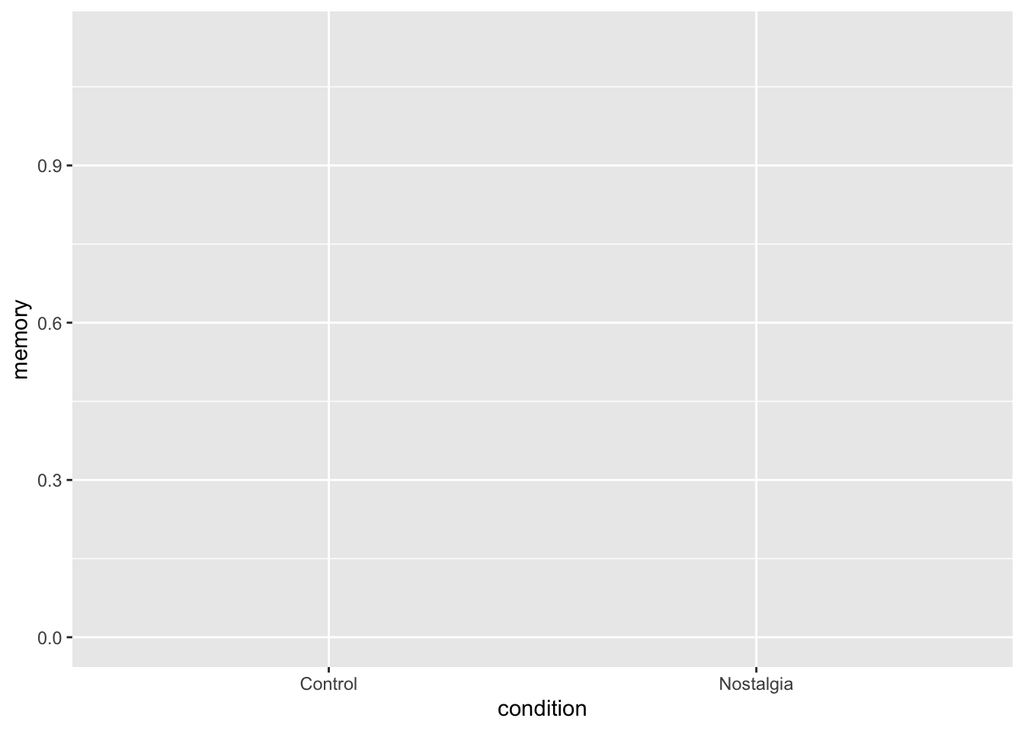

```r
myplot <- ggplot(data, aes(x = condition, y = memory))

myplot
```

### 2. Geometric object

Now adding geometric objects

Histogram

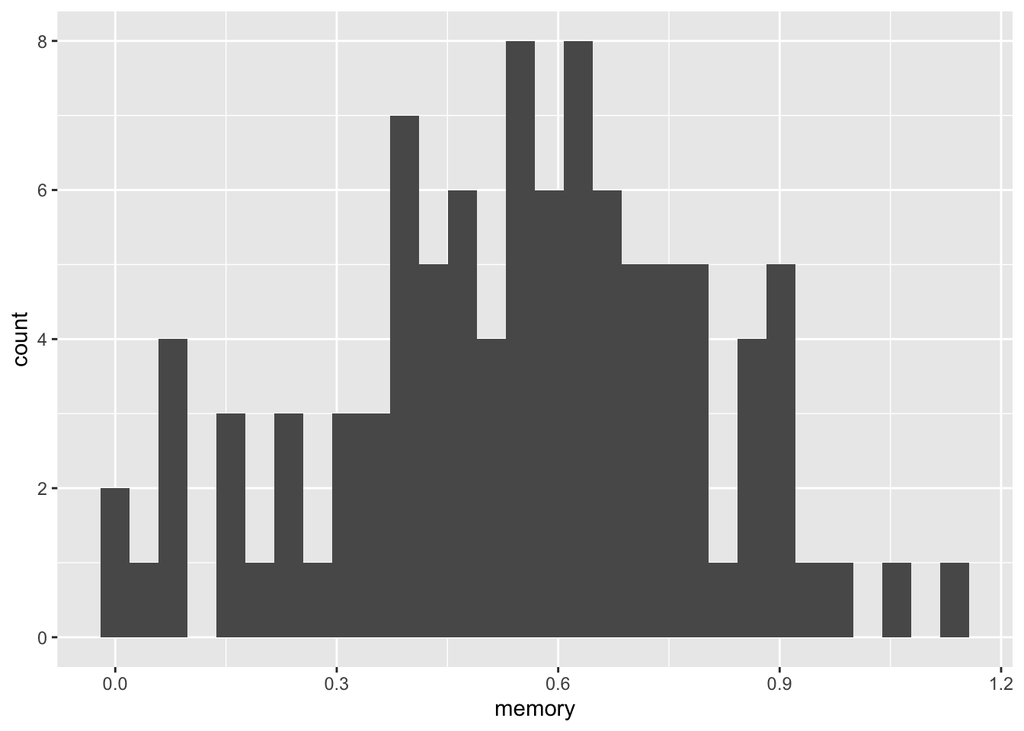

```r
myplot <- ggplot(data, aes(x = memory)) +
  geom_histogram()

myplot
```

Boxplot

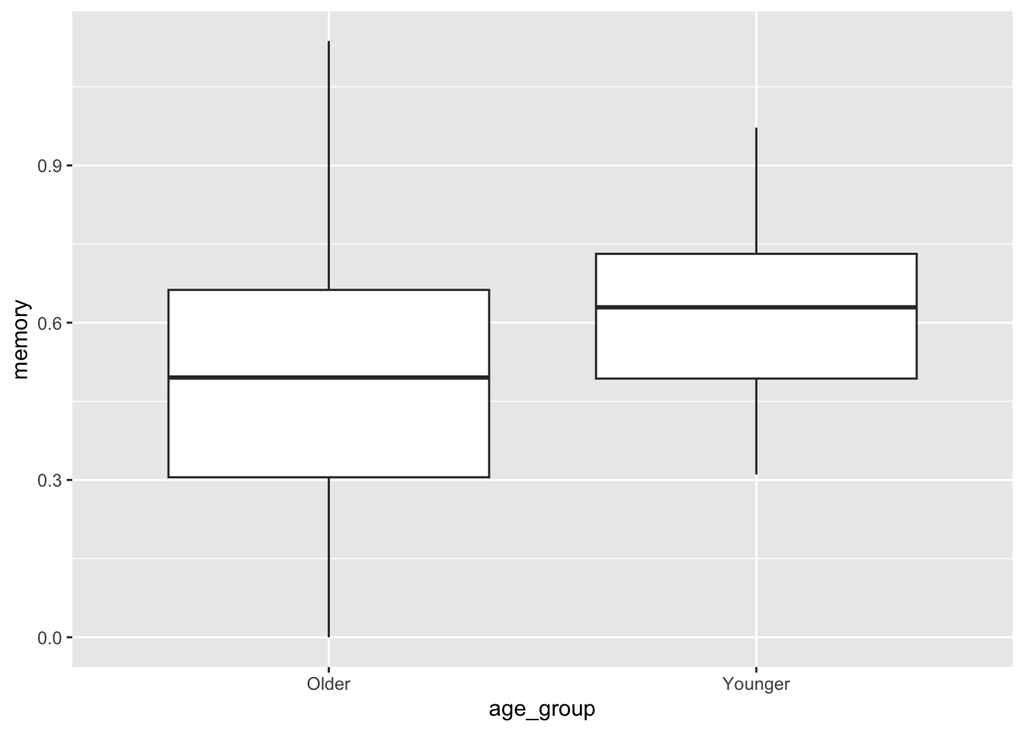

```r
myplot <- ggplot(data, aes(x = age_group, y = memory)) +
  geom_boxplot()

myplot
```

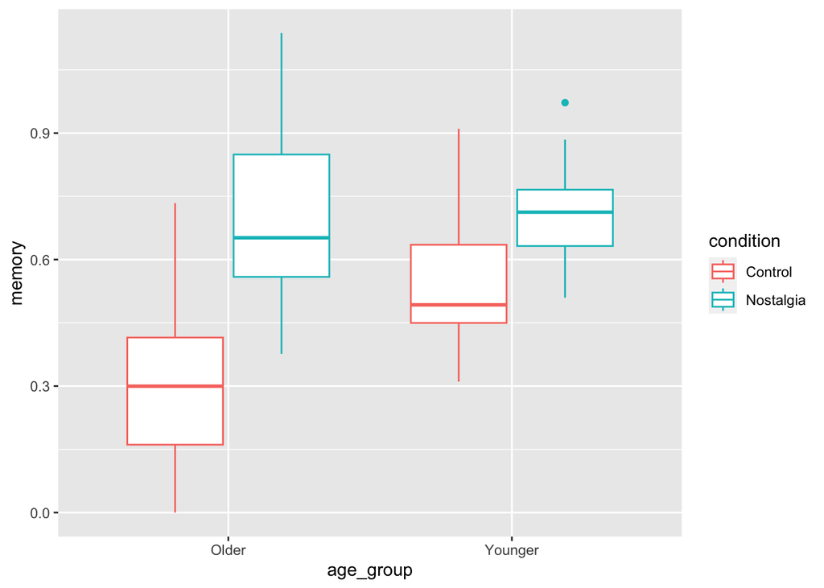

```r
myplot <- ggplot(data, aes(x = age_group, y = memory, color = condition)) +
  geom_boxplot()

myplot
```

Note: you can stack geometric objects

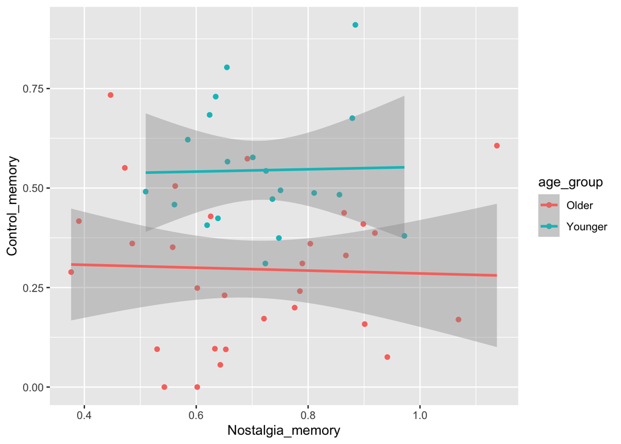

```r
myplot <- ggplot(data_wide, aes(x = Nostalgia_memory, y = Control_memory, color = age_group)) +
  geom_point() +
  geom_smooth(method = lm)

myplot
```

### 3. Statistical transformations

You can make statistical transformations

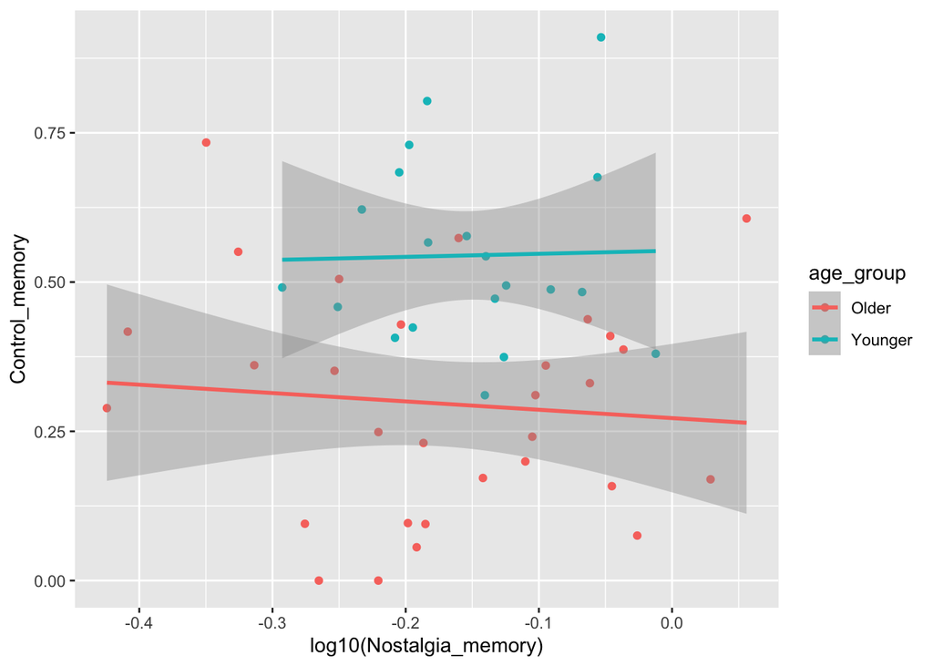

```r
myplot <- ggplot(data_wide, aes(x = log10(Nostalgia_memory), y = Control_memory, color = age_group)) +
  geom_point() +
  geom_smooth(method = lm)

myplot
```

### 4. Customize!

```r
# make a summary
mem_sum <- ddply(data, c("age_group", "condition"), summarise,
                            N = length(memory[!is.na(memory)]),
                            Mean = mean(memory, na.rm=TRUE),
                            SD = sd(memory, na.rm=TRUE),
                            SE = SD / sqrt(N))
```

You can customize as much as you want. Here are some examples:

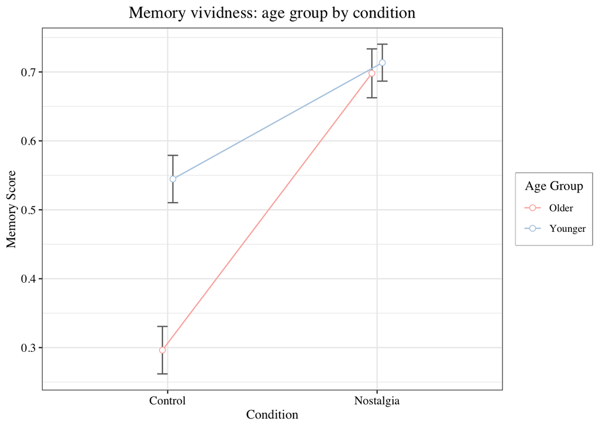

```r
myplot <- ggplot(mem_sum, aes(x=condition, y=Mean, colour=age_group, group = age_group)) +
  geom_errorbar(aes(ymin=Mean-SE, ymax=Mean+SE), colour="gray43", width=.1, position=position_dodge(0.1)) +
  geom_line(position=position_dodge(0.1)) +
  geom_point(position=position_dodge(0.1), size=2, shape=21, fill="white")  +
  xlab("Condition") +
  ylab("Memory Score") +
  ggtitle("Memory vividness: age group by condition") +
  scale_colour_brewer(palette = "Pastel1") +
  theme_bw() +
  labs(colour = "Age Group") +
  theme(legend.position = "right",
        text = element_text(family = "Times"),
        axis.text.x = element_text(colour = "black", size = 10, family  = "Times"),
        axis.text.y = element_text(colour = "black", size = 10, family = "Times"),
        plot.title = element_text(colour = "black", size = 14, hjust = 0.5, family = "Times"),
        legend.title.align = 0.5,
        legend.box.background = element_rect(colour = "gray43")
          )

myplot
```

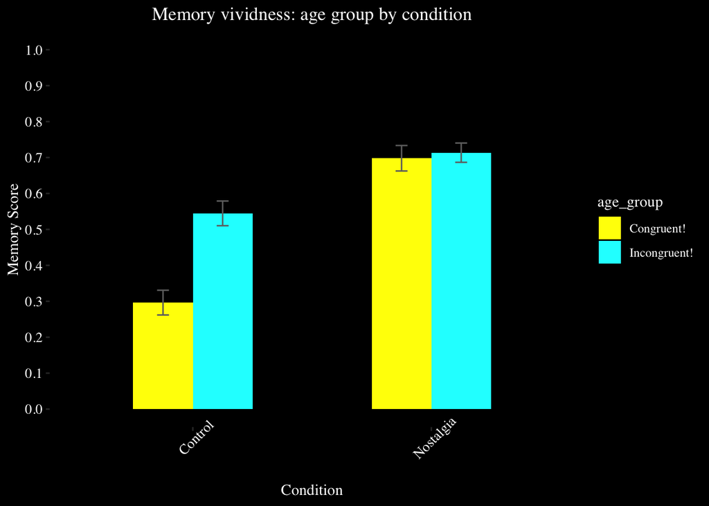

```r
myplot <- ggplot(mem_sum, aes(x=condition, y=Mean, fill=age_group)) +
  geom_bar(stat = "identity", width = 0.5, position=position_dodge(0.5)) +
  geom_errorbar(aes(ymin=Mean-SE, ymax=Mean+SE), colour="gray43", width=.1, position=position_dodge(0.5)) +
  xlab("Condition") +
  ylab("Memory Score") +
  expand_limits(y=1) +
  scale_y_continuous(breaks = seq(0,1, by =0.1)) +
  ggtitle("Memory vividness: age group by condition") +
  scale_fill_manual(name = "age_group",
                      breaks = c("Older","Younger", "Neutral"), #what they ARE called
                      labels = c("Congruent!", "Incongruent!", "Neutral!"), #what you WANT THEM TO BE called
                      values = c("yellow","cyan", "pink")) +
  theme_bw() +
  labs(fill = "Age Group") +
  theme(axis.line = element_line(size = 1, colour = "black"),
        panel.grid.major = element_blank(),
        panel.grid.minor = element_blank(),
        panel.border = element_blank(), panel.background = element_blank(),
        text = element_text(family = "Times", colour = "white"),
        plot.background = element_rect(fill = "black", colour = "black"),
        legend.background = element_blank(),
        legend.box.background = element_blank(),
        legend.key = element_rect(fill = "black"),
        plot.title = element_text(hjust = 0.5),
        axis.text.x = element_text(colour = "white", size = 10, angle = 45), #angle makes an angle!
        axis.text.y = element_text(colour = "white", size = 10),
        strip.background = element_rect(fill = "gray28"), #change the colors of your facet boxes
        strip.text = element_text(colour = "white"))
myplot
```

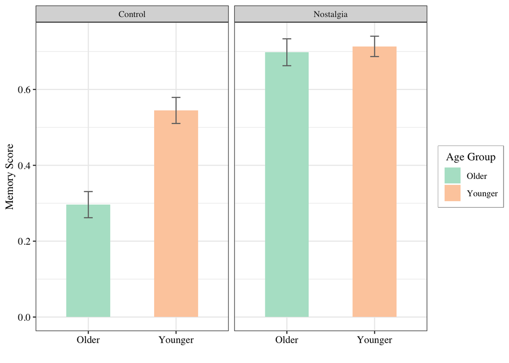

```r
myplot <- ggplot(mem_sum, aes(x=age_group, y=Mean, fill=age_group)) +
  geom_bar(stat = "identity", position=position_dodge(0.1), width = 0.5) +
  geom_errorbar(aes(ymin=Mean-SE, ymax=Mean+SE), colour="gray43", width=.1, position=position_dodge(0.1)) +
  xlab(" ") +
  ylab("Memory Score") +
  scale_fill_brewer(palette = "Pastel2") +
  theme_bw() +
  labs(fill = "Age Group") +
  theme(legend.position = "right",
        text = element_text(family = "Times"),
        axis.text.x = element_text(colour = "black", size = 10, family  = "Times"),
        axis.text.y = element_text(colour = "black", size = 10, family = "Times"),
        plot.title = element_text(colour = "black", size = 14, hjust = 0.5, family = "Times"),
        legend.title.align = 0.5,
        legend.box.background = element_rect(colour = "gray43")
          ) +
  facet_wrap(~condition)

myplot
```

# Section III Basic Stats

Independent Variable: Levels: Data type:

Dependent Variable: Data type:

Check variable types so that they align with data types

```r
str(data)
```

```
## 'data.frame':    100 obs. of  5 variables:
##  $ id       : chr  "sub-001" "sub-001" "sub-002" "sub-002" ...
##  $ age_group: chr  "Older" "Older" "Older" "Older" ...
##  $ gender   : chr  "Female" "Female" "Female" "Female" ...
##  $ condition: chr  "Nostalgia" "Control" "Nostalgia" "Control" ...
##  $ memory   : num  0.868 0.331 0.472 0.551 0.785 ...
```

```r
data$age_group = as.factor(data$age_group)
data$gender = as.factor(data$gender)
data$condition = as.factor(data$condition)
```

## Test Normality

Let’s look at it first

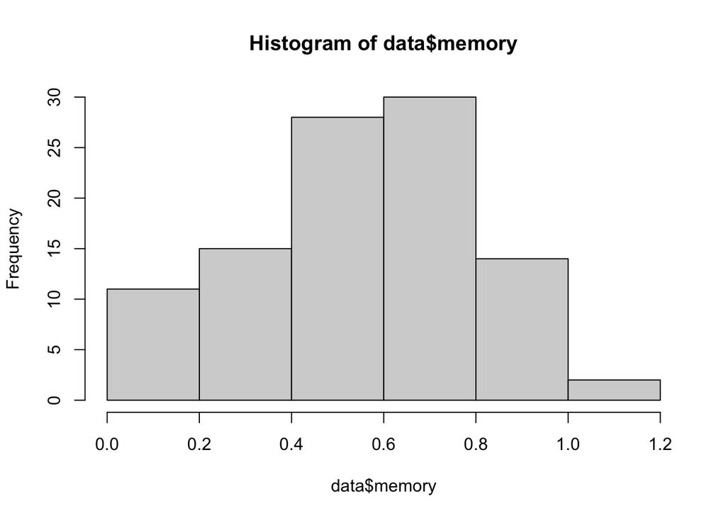

```r
hist(data$memory)
```

```r
library(moments)
skewness(data$memory)
```

```
## [1] -0.190439
```

**What is this??**

Skewness is a measure of symmetry, basically. Negative skewness = mean < median (left skew) Positive skewness = mean > median (right skew)

When you should worry: >1.96 or < -1.96

A perfectly non-skewed data is where the mean = median, skewness = 0.

```r
kurtosis(data$memory)
```

```
## [1] 2.669981
```

**What is this??**

Kurtosis is similar to skewness, in that it measures the data’s distribution. It measures the tail shape of the data distribution/ how “peaked” the distribution is.

A thin-tailed data distribution has too much data in the middle. A fat-tailed data distribution has too much data on the tails.

A perfect normal distribution has 0 excess kurtosis.

The acceptable range for this is similar to skewness, above.

```r
shapiro.test(data$memory)
```

```
##
##  Shapiro-Wilk normality test
##
## data:  data$memory
## W = 0.98871, p-value = 0.5621
```

**How to report**

> “A Shapiro-Wilk test demonstrated that the distribution of Memory was approximately normal (W = 0.99, p = 0.56; skewness = -0.19, kurtosis = 2.67).”

## Chi-Squared

```r
chisq.test(data$age_group, data$gender)
```

```
##
##  Pearson's Chi-squared test
##
## data:  data$age_group and data$gender
## X-squared = 0, df = 1, p-value = 1
```

**What is this??**

This tests if 2 categorical variables are related in some population.

If the p value is less than p < 0.05, we reject the null hypothesis that the distribution of the variables are independent. Basically, that the groups differ in gender distribution. In this example, they are actually perfectly matched by design.

**How to report**

> “An association between age group and gender was not observed, χ2(1) = 0, p=1.”

## Pearson’s Correlation

Let’s look at the relationship between nostalgia memory and control memory. To do this we need to use WIDE data.

```r
cor.test(data_wide$Nostalgia_memory, data_wide$Control_memory)
```

```
##
##  Pearson's product-moment correlation
##
## data:  data_wide$Nostalgia_memory and data_wide$Control_memory
## t = 0.05775, df = 48, p-value = 0.9542
## alternative hypothesis: true correlation is not equal to 0
## 95 percent confidence interval:
##  -0.2706405  0.2860193
## sample estimates:
##         cor
## 0.008335167
```

**How to report**

> “Memory vividness in the Nostalgia and Control conditions were not significantly correlated, r(48) = 0.008,t= 0.058, p > 0.05.”

## T-Tests

Independent (age group)

need to use wide again..but this time we need it wide where it is spread by age group…

```r
data_wide_age = reshape(data, idvar = c("id","condition","gender"),
                    timevar = "age_group",
                    direction = "wide")
```

```r
t.test(data_wide_age$memory.Older,data_wide_age$memory.younger)
```

```
##
##  One Sample t-test
##
## data:  data_wide_age$memory.Older
## t = 13.874, df = 59, p-value < 2.2e-16
## alternative hypothesis: true mean is not equal to 0
## 95 percent confidence interval:
##  0.4254651 0.5688738
## sample estimates:
## mean of x
## 0.4971695
```

what are our means?

```r
mean(data_wide_age$memory.Older,na.rm=TRUE)
```

```
## [1] 0.4971695
```

```r
sd(data_wide_age$memory.Older,na.rm=TRUE)
```

```
## [1] 0.2775715
```

```r
mean(data_wide_age$memory.Younger,na.rm=TRUE)
```

```
## [1] 0.6290732
```

```r
sd(data_wide_age$memory.Younger,na.rm=TRUE)
```

```
## [1] 0.1606722
```

Paired (condition)

```r
t.test(data_wide$Nostalgia_memory,data_wide$Control_memory, paired= TRUE )
```

```
##
##  Paired t-test
##
## data:  data_wide$Nostalgia_memory and data_wide$Control_memory
## t = 8.0939, df = 49, p-value = 1.373e-10
## alternative hypothesis: true mean difference is not equal to 0
## 95 percent confidence interval:
##  0.2319522 0.3851742
## sample estimates:
## mean difference
##       0.3085632
```

what are our means?

```r
mean(data_wide$Nostalgia_memory,na.rm=TRUE)
```

```
## [1] 0.7042126
```

```r
sd(data_wide$Nostalgia_memory,na.rm=TRUE)
```

```
## [1] 0.1671901
```

```r
mean(data_wide$Control_memory,na.rm=TRUE)
```

```
## [1] 0.3956494
```

```r
sd(data_wide$Control_memory,na.rm=TRUE)
```

```
## [1] 0.2128585
```

**How to report**

> “Across participants, memory vividness was significantly higher in the Nostalgia condition (M = 0.70, SD = 0.17) than the Control condition (M = 0.40, SD = .21), t(49) = 8.09, p < 0.001.”

## Two-Way ANOVA

use LONG data

main effects only. We wont really use this one but just so you know how to do it.

```r
model <- aov(memory~condition + age_group, data= data )
summary(model)
```

```
##             Df Sum Sq Mean Sq F value   Pr(>F)
## condition    1  2.380  2.3803   72.78 1.97e-13 ***
## age_group    1  0.418  0.4176   12.77 0.000551 ***
## Residuals   97  3.172  0.0327
## ---
## Signif. codes:  0 '***' 0.001 '**' 0.01 '*' 0.05 '.' 0.1 ' ' 1
```

main effects and iteractions

```r
model <- aov(memory~condition * age_group, data= data )
summary(model)
```

```
##                     Df Sum Sq Mean Sq F value   Pr(>F)
## condition            1 2.3803  2.3803   80.27 2.56e-14 ***
## age_group            1 0.4176  0.4176   14.08  0.00030 ***
## condition:age_group  1 0.3253  0.3253   10.97  0.00131 **
## Residuals           96 2.8469  0.0297
## ---
## Signif. codes:  0 '***' 0.001 '**' 0.01 '*' 0.05 '.' 0.1 ' ' 1
```

main effects and iteractions and a covariate

```r
model <- aov(memory~condition * age_group + gender, data= data )
summary(model)
```

```
##                     Df Sum Sq Mean Sq F value   Pr(>F)
## condition            1 2.3803  2.3803  80.096  2.9e-14 ***
## age_group            1 0.4176  0.4176  14.051 0.000306 ***
## gender               1 0.0237  0.0237   0.797 0.374166
## condition:age_group  1 0.3253  0.3253  10.948 0.001325 **
## Residuals           95 2.8232  0.0297
## ---
## Signif. codes:  0 '***' 0.001 '**' 0.01 '*' 0.05 '.' 0.1 ' ' 1
```

### Effect sizes

When reporting statistics in papers, you need to include eta squared, or effect size. These values do not immediately appear with this call. So, you have to do this:

```r
library(lsr)
etaSquared(model, type = 2, anova = FALSE)
```

```
##                          eta.sq eta.sq.part
## condition           0.398701503 0.457440740
## age_group           0.069943150 0.128848319
## gender              0.003968669 0.008322525
## condition:age_group 0.054496588 0.103333266
```

### Post Hocs, using AOV

What do the main effects mean??

```r
TukeyHSD(model)
```

```
##   Tukey multiple comparisons of means
##     95% family-wise confidence level
##
## Fit: aov(formula = memory ~ condition * age_group + gender, data = data)
##
## $condition
##                        diff       lwr       upr p adj
## Nostalgia-Control 0.3085632 0.2401163 0.3770101     0
##
## $age_group
##                    diff        lwr       upr     p adj
## Younger-Older 0.1319038 0.06204541 0.2017621 0.0003055
##
## $gender
##                    diff         lwr        upr     p adj
## Male-Female -0.03078525 -0.09923217 0.03766168 0.3741656
##
## $`condition:age_group`
##                                         diff         lwr         upr     p adj
## Nostalgia:Older-Control:Older      0.4017081  0.28530894  0.51810733 0.0000000
## Control:Younger-Control:Older      0.2483349  0.11819667  0.37847318 0.0000161
## Nostalgia:Younger-Control:Older    0.4171807  0.28704248  0.54731899 0.0000000
## Control:Younger-Nostalgia:Older   -0.1533732 -0.28351147 -0.02323495 0.0140812
## Nostalgia:Younger-Nostalgia:Older  0.0154726 -0.11466566  0.14561085 0.9895172
## Nostalgia:Younger-Control:Younger  0.1688458  0.02628649  0.31140512 0.0134669
```

Ok, but what do all of those interaction effects mean? Let us explore with a simple effects test. Let’s just pretend, first that we had a CONDITION X AGE interaction.

First, split up into separate data sets.

```r
Nostalgia = subset(data, condition == "Nostalgia")
Control = subset(data, condition == "Control")
```

Then, run ANOVAs on group within each condition

```r
N_Out = aov(memory ~ age_group, data = Nostalgia)
C_Out = aov(memory ~ age_group, data = Control)

summary(N_Out)
```

```
##             Df Sum Sq  Mean Sq F value Pr(>F)
## age_group    1 0.0029 0.002873   0.101  0.752
## Residuals   48 1.3668 0.028475
```

```r
summary(C_Out)
```

```
##             Df Sum Sq Mean Sq F value   Pr(>F)
## age_group    1   0.74  0.7400      24 1.14e-05 ***
## Residuals   48   1.48  0.0308
## ---
## Signif. codes:  0 '***' 0.001 '**' 0.01 '*' 0.05 '.' 0.1 ' ' 1
```

Do a post of to look at pairwise

```r
TukeyHSD(N_Out)
```

```
##   Tukey multiple comparisons of means
##     95% family-wise confidence level
##
## Fit: aov(formula = memory ~ age_group, data = Nostalgia)
##
## $age_group
##                    diff        lwr       upr     p adj
## Younger-Older 0.0154726 -0.0824707 0.1134159 0.7521432
```

```r
TukeyHSD(C_Out)
```

```
##   Tukey multiple comparisons of means
##     95% family-wise confidence level
##
## Fit: aov(formula = memory ~ age_group, data = Control)
##
## $age_group
##                    diff       lwr       upr    p adj
## Younger-Older 0.2483349 0.1464136 0.3502563 1.14e-05
```

Split it the other way now

```r
Old = subset(data, age_group == "Older")
Young = subset(data, age_group == "Younger")
```

```r
O_Out = aov(memory ~ condition, data = Old)
Y_Out = aov(memory ~ condition, data = Young)

summary(O_Out)
```

```
##             Df Sum Sq Mean Sq F value   Pr(>F)
## condition    1  2.421  2.4205   66.06 3.74e-11 ***
## Residuals   58  2.125  0.0366
## ---
## Signif. codes:  0 '***' 0.001 '**' 0.01 '*' 0.05 '.' 0.1 ' ' 1
```

```r
summary(Y_Out)
```

```
##             Df Sum Sq Mean Sq F value   Pr(>F)
## condition    1 0.2851 0.28509   15.01 0.000409 ***
## Residuals   38 0.7217 0.01899
## ---
## Signif. codes:  0 '***' 0.001 '**' 0.01 '*' 0.05 '.' 0.1 ' ' 1
```

Do a post of to look at pairwise

```r
TukeyHSD(O_Out)
```

```
##   Tukey multiple comparisons of means
##     95% family-wise confidence level
##
## Fit: aov(formula = memory ~ condition, data = Old)
##
## $condition
##                        diff       lwr       upr p adj
## Nostalgia-Control 0.4017081 0.3027754 0.5006408     0
```

```r
TukeyHSD(Y_Out)
```

```
##   Tukey multiple comparisons of means
##     95% family-wise confidence level
##
## Fit: aov(formula = memory ~ condition, data = Young)
##
## $condition
##                        diff        lwr       upr     p adj
## Nostalgia-Control 0.1688458 0.08062174 0.2570699 0.0004092
```

**What is all of this??**

We used ANOVA to determine if there are any statistically significant differences between conditions on a given dependent variable.

The null hypothesis states that the groups are *all the same*, and that the means are *not* statistically different from each other.

If a significant difference is found, it is called a **main effect**, and must then be interpreted using a post-hoc test. It spits out something called an **F ratio**, which is **F = variation BETWEEN samples/ variation WITHIN samples**. The null hypothesis says that the F ratio is 1.

So, if it is greater than 1, it means that the variation BETWEEN your sample is greater than the variation WITHIN your sample. This means that there is something acting upon your data that makes a change in it that is OUTSIDE of the variation the comes from within individuals.

Post hocs let you know where that main effect is coming from. They are *a posteriori* tests, which mean that they are performed *after* the ANOVA. Performing them before the ANOVA will increase your chances of obtaining a Type 1 error (false positive), and is generally considered poor practice.

**How to report**

Note: If you have an interaction effect, you usually only report that (not any sig main effects).

> “A 2-Way ANOVA revealed a significant interaction of Condition X Age Group, F(1,95) = 10.95, p < 0.01,η2_partial = 0.10. Post-hoc analysis using Tukey’s HSD indicated that memory vividness was great during the Nostalgia condition than the Control condition across subjects, and, during the Control condition only, older adults had less vivid memories than younger adults”.